# CaseStudy2

Allen Ansari

April 17, 2019

Github link: https://github.com/allenansari174/CaseStudy2DDS

YouTube Link: https://youtu.be/JlHU73MKJVM

## Introduction

The reduction in staff and employees in a company through normal means, such as retirement and resignation, called attrition. Employers generally consider attrition a loss of valuable employees and talent because when employees leave a company, they take with them much-needed skills and qualifications that they developed during their carrier. In this Study we are looking to find any relationship between attrition and other variables like age, job level, monthly incom and etc that given by our client. Our client is also interested in learning about any job role specific trends that may exist in the data set.

```r
# required libraries
library(caret)
library(ggplot2)
library(dplyr)
library(MLmetrics)
library(arules)
library(corrplot)
library(readxl)
library(polycor)
library(corrgram)
library(caTools)
library(class)
library(rpart)
library(e1071)
library(MASS)
library(fpc)
library(pROC)
library(ROCR)
library(Information)
```

```r
# Data importing
setwd("E:/University/Doing Data Science/UNIT 14")
employee <- read.csv("CaseStudy2-data.csv")
employee_Attrition_Test <- read.csv("CaseStudy2Validation No Attrition.csv")
employee_Salary_Test <- read_excel("CaseStudy2Validation No Salary.xlsx")
```

## Overview of the dataset

This dataset gives the information about the factors that lead to employee attrition which includes total 37 variables and 870 observations. Two additional data set of 300 observations are given that do not have the labels. We will refer to these data sets as the “validation sets” to predict attrition and monthly income.

```r
#Unnecessary features
#1. Employee ID - Considering it as a unique employee identification number. It would not add much value to analysis
#2. StandardHours - the value is 80 across all the rows in the dataset, it can be deleted.
#3. Employee Count - the value is 1 across all the rows in the dataset, it can be deleted.
#4. Over 18 - considering all employees are over 18
employee$ID <- NULL
employee$EmployeeNumber <- NULL
employee$StandardHours <- NULL
employee$EmployeeCount <- NULL
employee$Over18 <- NULL

#Converting features into categorical type
employee$NumCompaniesWorked <- as.factor(employee$NumCompaniesWorked)
employee$PerformanceRating <- as.factor(employee$PerformanceRating)
employee$Education <- as.factor(employee$Education)
employee$EnvironmentSatisfaction <- as.factor(employee$EnvironmentSatisfaction)
employee$RelationshipSatisfaction <- as.factor(employee$RelationshipSatisfaction)
employee$WorkLifeBalance <- as.factor(employee$WorkLifeBalance)
employee$JobLevel <- as.factor(employee$JobLevel)
employee$JobInvolvement <- as.factor(employee$JobInvolvement)
employee$JobSatisfaction <- as.factor(employee$JobSatisfaction)
employee$StockOptionLevel <- as.factor(employee$StockOptionLevel)
employee$TrainingTimesLastYear <- as.factor(employee$TrainingTimesLastYear)

# data cleaning for CaseStudy2Validation No Salary
employee_Salary_Test$ID <- NULL
employee_Salary_Test$EmployeeNumber <- NULL
employee_Salary_Test$StandardHours <- NULL
employee_Salary_Test$EmployeeCount <- NULL
employee_Salary_Test$Over18 <- NULL

#Converting features into categorical type
employee_Salary_Test$NumCompaniesWorked <- as.factor(employee_Salary_Test$NumCompaniesWorked)
employee_Salary_Test$PerformanceRating <- as.factor(employee_Salary_Test$PerformanceRating)
employee_Salary_Test$Education <- as.factor(employee_Salary_Test$Education)
employee_Salary_Test$EnvironmentSatisfaction <- as.factor(employee_Salary_Test$EnvironmentSatisfaction)
employee_Salary_Test$RelationshipSatisfaction <- as.factor(employee_Salary_Test$RelationshipSatisfaction)
employee_Salary_Test$WorkLifeBalance <- as.factor(employee_Salary_Test$WorkLifeBalance)
employee_Salary_Test$JobLevel <- as.factor(employee_Salary_Test$JobLevel)
employee_Salary_Test$JobInvolvement <- as.factor(employee_Salary_Test$JobInvolvement)
employee_Salary_Test$JobSatisfaction <- as.factor(employee_Salary_Test$JobSatisfaction)
employee_Salary_Test$StockOptionLevel <- as.factor(employee_Salary_Test$StockOptionLevel)
employee_Salary_Test$TrainingTimesLastYear <- as.factor(employee_Salary_Test$TrainingTimesLastYear)


# data cleaning for CaseStudy2Validation No Attrition
employee_Attrition_Test$ID <- NULL
employee_Attrition_Test$EmployeeNumber <- NULL
employee_Attrition_Test$StandardHours <- NULL
employee_Attrition_Test$EmployeeCount <- NULL
employee_Attrition_Test$Over18 <- NULL

#Converting features into categorical type
employee_Attrition_Test$NumCompaniesWorked <- as.factor(employee_Attrition_Test$NumCompaniesWorked)
employee_Attrition_Test$PerformanceRating <- as.factor(employee_Attrition_Test$PerformanceRating)
employee_Attrition_Test$Education <- as.factor(employee_Attrition_Test$Education)
employee_Attrition_Test$EnvironmentSatisfaction <- as.factor(employee_Attrition_Test$EnvironmentSatisfaction)
employee_Attrition_Test$RelationshipSatisfaction <- as.factor(employee_Attrition_Test$RelationshipSatisfaction)
employee_Attrition_Test$WorkLifeBalance <- as.factor(employee_Attrition_Test$WorkLifeBalance)
employee_Attrition_Test$JobLevel <- as.factor(employee_Attrition_Test$JobLevel)
employee_Attrition_Test$JobInvolvement <- as.factor(employee_Attrition_Test$JobInvolvement)
employee_Attrition_Test$JobSatisfaction <- as.factor(employee_Attrition_Test$JobSatisfaction)
employee_Attrition_Test$StockOptionLevel <- as.factor(employee_Attrition_Test$StockOptionLevel)
employee_Attrition_Test$TrainingTimesLastYear <- as.factor(employee_Attrition_Test$TrainingTimesLastYear)
```

# Exploratory data analysis

```r
# distribution of Attrition rates across data set
table(employee$Attrition) %>% prop.table()
```

```
##
##        No       Yes
## 0.8390805 0.1609195
```

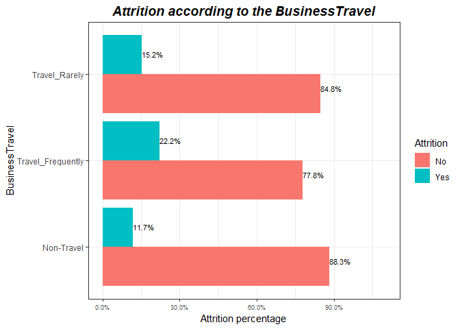

```r
# Function to create bar plot
pplot <- function(feat,var) {
  feat <- substitute(feat)
  var <- substitute(var)

  ggplot(data = employee, aes_(x = feat, fill=var)) +
     geom_bar(aes( y=..count../tapply(..count.., ..x.. ,sum)[..x..]), position="dodge" ) + theme_bw() + geom_text(aes( y=..count../tapply(..count.., ..x.. ,sum)[..x..], label=scales::percent(..count../tapply(..count.., ..x.. ,sum)[..x..]) ),
            stat="count", position=position_dodge(0.8), vjust=0, hjust=0,size=3)+
   labs(x=paste(feat), y="Attrition percentage")+ theme(axis.text.x=element_text(size=7),
    plot.title = element_text(size=14,hjust = 0.5, face="bold.italic"))+ coord_flip()+
  ggtitle(paste("Attrition according to the" ,feat)) + scale_y_continuous(labels = scales::percent, limits=c(0,1.1))

 }
# bar plot of Business Travel and Attrition
pplot(BusinessTravel,Attrition)
```

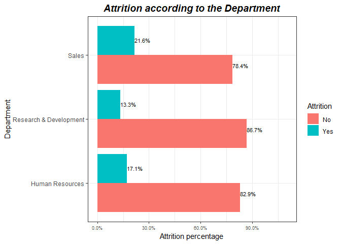

```r
# bar plot of Department and Attrition
pplot(Department,Attrition)
```

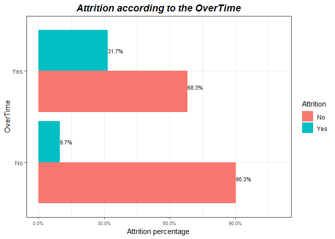

```r
# bar plot of Over Time and Attrition
pplot(OverTime,Attrition)
```

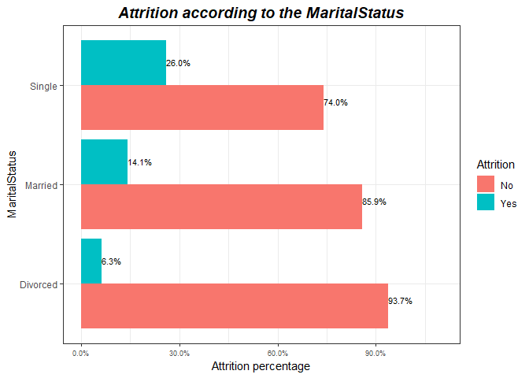

```r
# bar plot of Performance Rating and Attrition
pplot(MaritalStatus,Attrition)
```

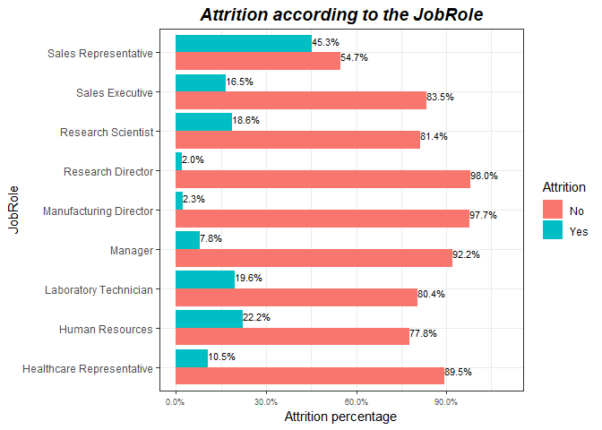

```r
# bar plot of Job role Rating and Attrition
pplot(JobRole,Attrition)
```

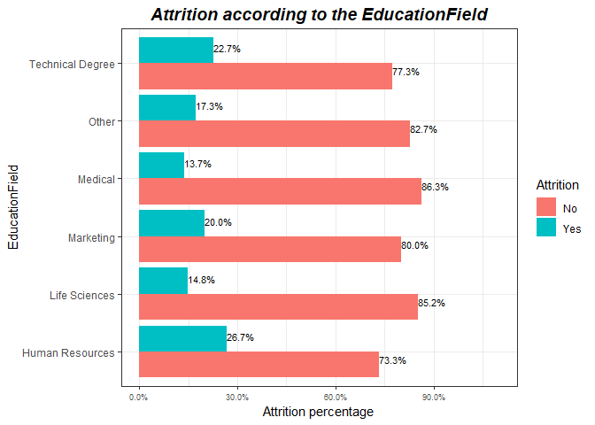

```r
# bar plot of Education Field and Attrition
pplot(EducationField,Attrition)
```

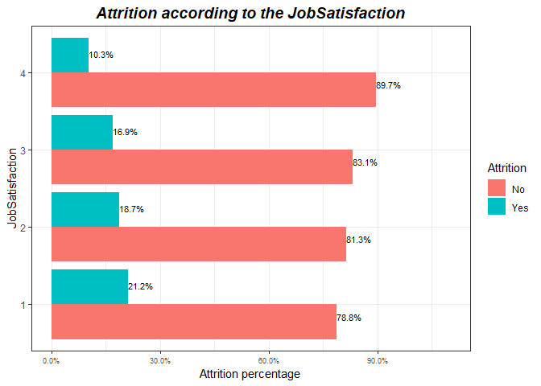

```r
# bar plot of Job satisfaction and Attrition
pplot(JobSatisfaction,Attrition)
```

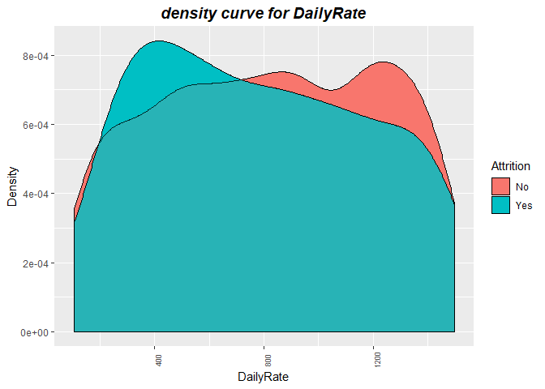

```r
# Density plot Function
dplot <- function(feat,var) {
  feat <- substitute(feat)
  var <- substitute(var)
  ggplot(data = employee, aes_(x = feat, fill=var)) +
   geom_density()+ geom_density(alpha=0.2)+
  labs(x=paste(feat), y="Density")+ theme(axis.text.x=element_text(size=7, angle=90),
    plot.title = element_text(size=14,hjust = 0.5, face="bold.italic"))+
  ggtitle(paste("density curve for" ,feat))
}
# DailyRate Density Plot
dplot(DailyRate,Attrition)
```

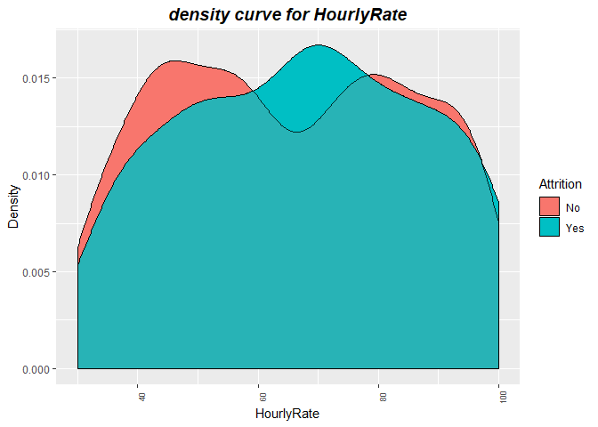

```r
# HourlyRate Density Plot
dplot(HourlyRate,Attrition)
```

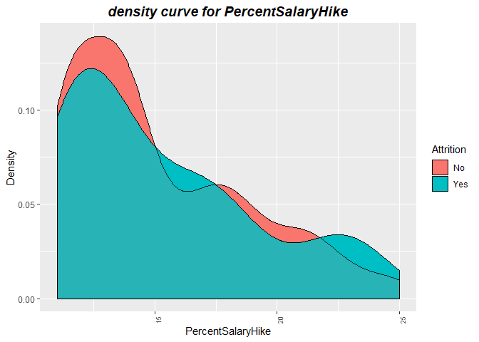

```r
# PercentSalaryHike Density Plot
dplot(PercentSalaryHike,Attrition)
```

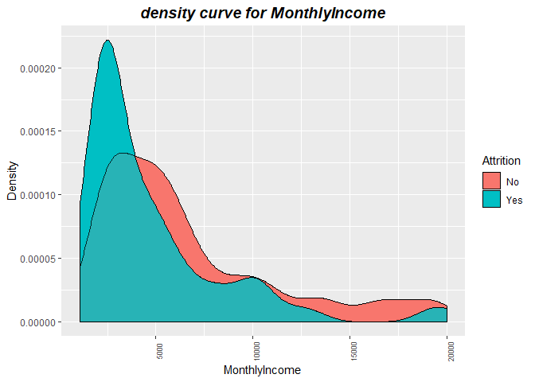

```r
# MonthlyIncome Density Plot
dplot(MonthlyIncome,Attrition)
```

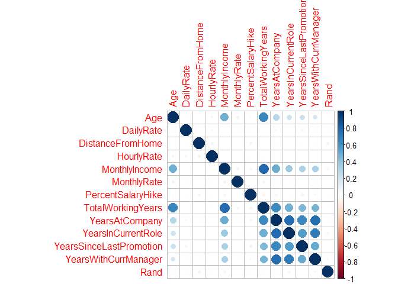

```r
# Correlation between attributes
# Most of the features given in this dataset are poorly correlated to each other, with the exception of YearsAtCompany, YearsInCurrentRole, YearsSinceLastPromotion , YearsWithCurrManager and TotalWorkingYears. Also there us positive correlation between TotalWorkingYers and Age and MonthlyIncom which make sense.
  employee %>%
  select_if(is.numeric) %>%
  cor()%>%
  corrplot::corrplot()
```

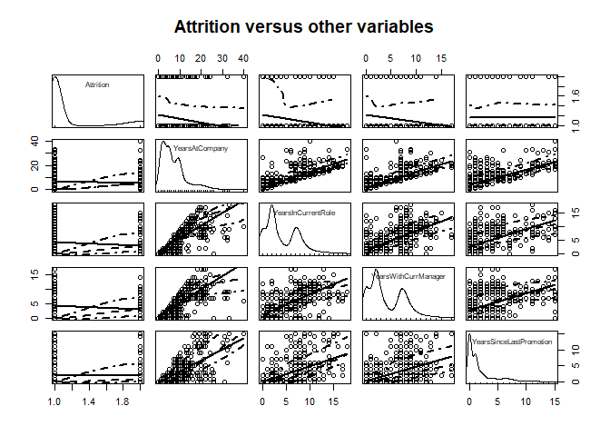

```r
# Scatter plot
 car::scatterplotMatrix(~Attrition+YearsAtCompany+YearsInCurrentRole+YearsWithCurrManager+YearsSinceLastPromotion,data=employee,main="Attrition versus other variables",ellipes=T,col = "black",by.groups = T)
```

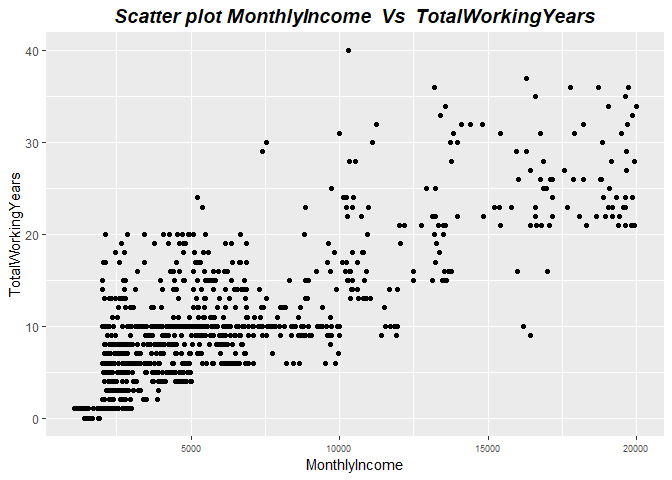

```r
# Function to creat ScatterPlot
Splot <- function(var1,var2) {
  var1 <- substitute(var1)
  var2 <- substitute(var2)

  ggplot(data = employee, aes_(x = var1, y=var2)) +
    geom_point() + labs(x=paste(var1), y=paste(var2))+
    theme(axis.text.x=element_text(size=7),
    plot.title = element_text(size=14,hjust = 0.5, face="bold.italic"))+
  ggtitle(paste("Scatter plot",var1, " Vs ", var2))
}
#Scatter plot for Monthly Income vs total working years
Splot(MonthlyIncome,TotalWorkingYears)
```

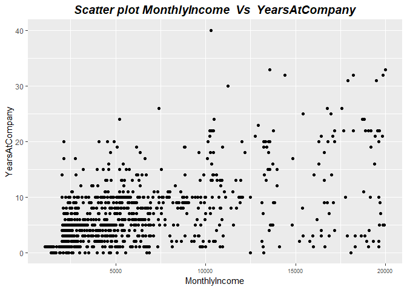

```r
#Scatter plot for Monthly Income vs years at company
Splot(MonthlyIncome,YearsAtCompany)
```

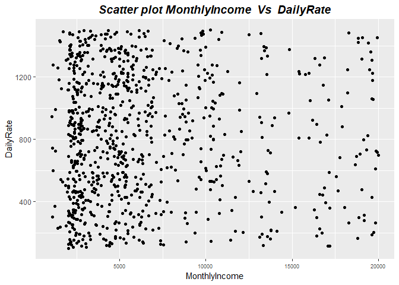

```r
#Scatter plot for Monthly Income vs daily rate
Splot(MonthlyIncome,DailyRate)
```

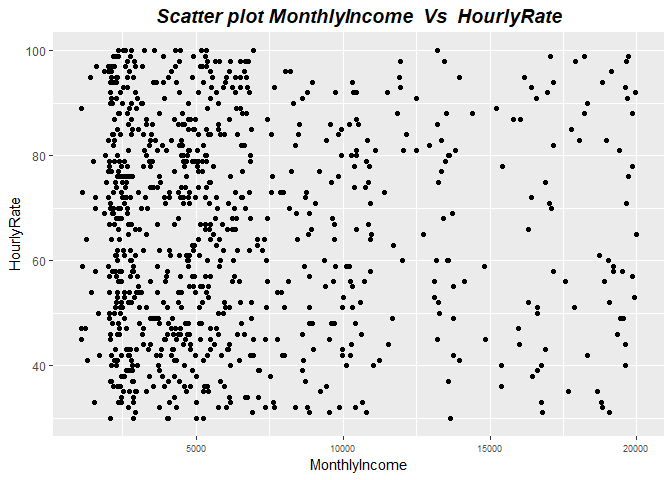

```r
#Scatter plot for Monthly Income vs hourly rate
Splot(MonthlyIncome,HourlyRate)
```

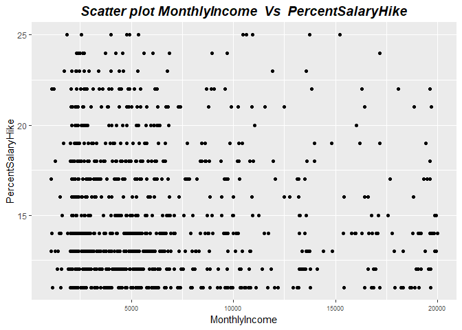

```r
#Scatter plot for Monthly Income vs Percent Salary Hike
Splot(MonthlyIncome,PercentSalaryHike)
```

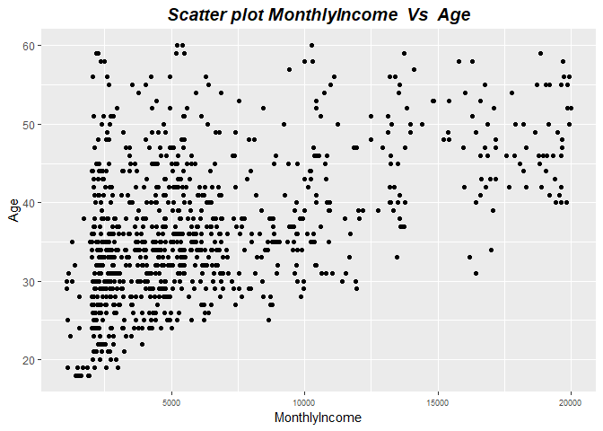

```r
#Scatter plot for Monthly Income vs monthly rate
Splot(MonthlyIncome,Age)
```

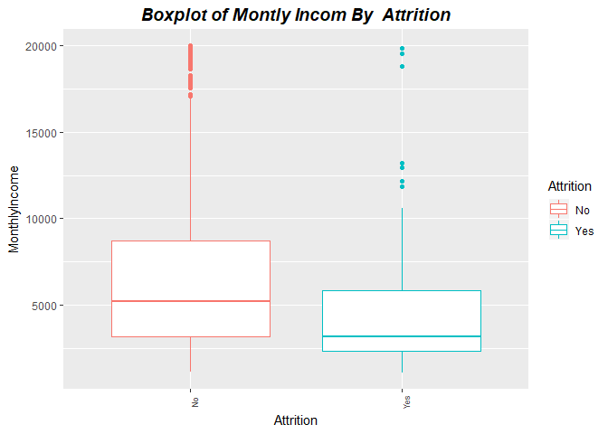

```r
bplot <- function(var1,var2) {
  var1 <- substitute(var1)
  var2 <- substitute(var2)
ggplot(data = employee, aes_(x = var1, y = var2)) + geom_boxplot(aes(color=Attrition)) + theme(axis.text.x=element_text(size=7, angle=90), plot.title = element_text(size=14,hjust = 0.5, face="bold.italic"))+
  ggtitle(paste("Boxplot of Montly Incom By ",var1)) + labs(x=var1,y=var2)
}
# Box Plot of Monthly Income by Attrition
bplot(Attrition,MonthlyIncome)
```

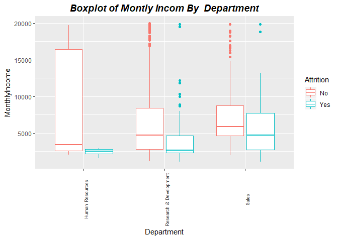

```r
# Box Plot of Monthly Income by Department
bplot(Department,MonthlyIncome)
```

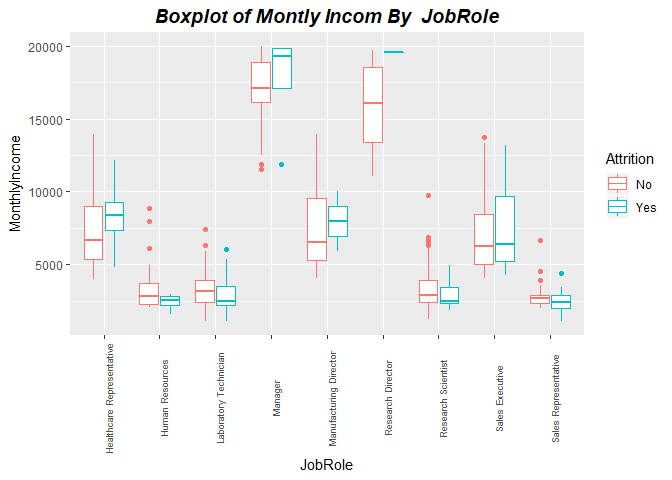

```r
# Box Plot of Monthly Income by Job Role
bplot(JobRole,MonthlyIncome)
```

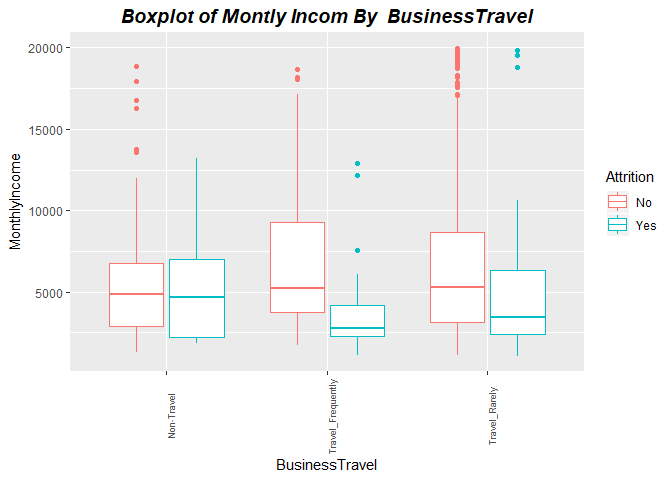

```r
# Box Plot of Monthly Income by Business Travel
bplot(BusinessTravel,MonthlyIncome)
```

# Observations

The following list highlights from this exploratory data analysis:

- Employees that studied in HR, Marketing and Technical had a higher attrition rate than all the others.
- Sales representatives had a tremendously high attrition rate, managers, directors and people in the more senior roles tended to remain in the company’s workforce.
- Singles were more likely to leave the company than divorced and married employees.
- R&D department compared to the sales and HR departments was slightly less attrition rate.
- Employees that were not satisfied in the company, that were very unhappy in their team, that did not have a healthy work life balance, and that were not happy with their work environment were more likely to leave. In all cases we noticed that the attrition rate for ‘very unhappy’ employees was around double than for the other cases.
- Overtime had a negative effect on attrition. We noticed that employees were more likely to leave when they did overtime.
- Employees that travelled frequently were more likely to leave.
- Employee who works with sales has highest monthly incom and HR has lowest Incom
- there is linear relationship between monthly income and years at company, Age and total working years

# Data Analysis

For data analysis we devided our dataset into training and test(70/30). Two methods used for attrition classification:Logistic Regression and Naive Bayes . To analysis monthly incom linear regression has been used.

## logistic Regression

```r
# divide data into training(70%) and test(30%) dataset
set.seed(101)
split = sample.split(employee$Attrition, SplitRatio = 0.7)
employee.train = subset(employee, split == TRUE)
employee.test = subset(employee, split == FALSE)
# distribution of Attrition rates across train & test set
table(employee.train$Attrition) %>% prop.table()
```

```
##
##        No       Yes
## 0.8390805 0.1609195
```

```r
table(employee.test$Attrition) %>% prop.table()
```

```
##
##        No       Yes
## 0.8390805 0.1609195
```

```r
#Logistic regression Model
FullModel <- glm(Attrition ~  ., data = employee.train, family = binomial)
predict_employee_Full <- predict(FullModel,newdata = employee.test,type = 'response')

# Using roc function to find best classifier threshold
#create an roc object
roc_obj <- roc(employee.test$Attrition, predict_employee_Full)
#review the roc object
roc_obj
```

```
##
## Call:
## roc.default(response = employee.test$Attrition, predictor = predict_employee_Full)
##
## Data: predict_employee_Full in 219 controls (employee.test$Attrition No) < 42 cases (employee.test$Attrition Yes).
## Area under the curve: 0.8332
```

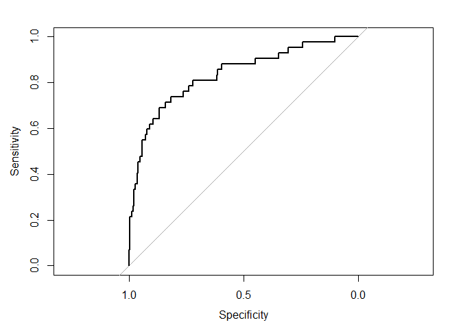

```r
plot(roc_obj)
```

```r
#get the "best" "threshold"
# there are lots of other options for other metrics as well
coords(roc_obj, "best", "threshold")
```

```
##   threshold specificity sensitivity
##   0.1668550   0.8675799   0.6904762
```

```r
# using best threshold to create the result
Results_Full <- ifelse(predict_employee_Full > 0.07,"Yes","No")
confusionMatrix(as.factor(Results_Full), employee.test$Attrition)
```

```
## Confusion Matrix and Statistics
##
##           Reference
## Prediction  No Yes
##        No  165  10
##        Yes  54  32
##
##                Accuracy : 0.7548
##                  95% CI : (0.698, 0.8057)
##     No Information Rate : 0.8391
##     P-Value [Acc > NIR] : 0.9998
##
##                   Kappa : 0.3621
##
##  Mcnemar's Test P-Value : 7.658e-08
##
##             Sensitivity : 0.7534
##             Specificity : 0.7619
##          Pos Pred Value : 0.9429
##          Neg Pred Value : 0.3721
##              Prevalence : 0.8391
##          Detection Rate : 0.6322
##    Detection Prevalence : 0.6705
##       Balanced Accuracy : 0.7577
##
##        'Positive' Class : No
##
```

```r
# Setp Model
StepModel <- stepAIC(FullModel,trace = FALSE)
#Final Model
summary(StepModel)
```

```
##
## Call:
## glm(formula = Attrition ~ BusinessTravel + DailyRate + DistanceFromHome +
##     EnvironmentSatisfaction + HourlyRate + JobInvolvement + JobLevel +
##     JobRole + JobSatisfaction + MaritalStatus + NumCompaniesWorked +
##     OverTime + PerformanceRating + StockOptionLevel + TotalWorkingYears +
##     WorkLifeBalance + YearsInCurrentRole + YearsSinceLastPromotion,
##     family = binomial, data = employee.train)
##
## Deviance Residuals:
##     Min       1Q   Median       3Q      Max
## -1.8827  -0.3258  -0.1066  -0.0119   3.4523
##
## Coefficients:
##                                   Estimate Std. Error z value Pr(>|z|)
## (Intercept)                     -2.660e+00  1.824e+00  -1.458 0.144844
## BusinessTravelTravel_Frequently  2.550e+00  7.967e-01   3.201 0.001371 **
## BusinessTravelTravel_Rarely      1.656e+00  7.138e-01   2.319 0.020376 *
## DailyRate                       -9.475e-04  4.445e-04  -2.132 0.033042 *
## DistanceFromHome                 7.394e-02  2.106e-02   3.511 0.000446 ***
## EnvironmentSatisfaction2        -1.288e+00  5.427e-01  -2.373 0.017664 *
## EnvironmentSatisfaction3        -1.220e+00  4.909e-01  -2.485 0.012956 *
## EnvironmentSatisfaction4        -1.489e+00  5.134e-01  -2.901 0.003722 **
## HourlyRate                       2.288e-02  9.137e-03   2.504 0.012266 *
## JobInvolvement2                 -1.193e+00  7.467e-01  -1.597 0.110262
## JobInvolvement3                 -2.071e+00  7.037e-01  -2.943 0.003255 **
## JobInvolvement4                 -2.349e+00  8.628e-01  -2.723 0.006473 **
## JobLevel2                       -1.871e+00  8.393e-01  -2.229 0.025820 *
## JobLevel3                       -3.427e-01  1.038e+00  -0.330 0.741380
## JobLevel4                       -1.456e+00  1.712e+00  -0.850 0.395334
## JobLevel5                        2.286e+00  2.240e+00   1.020 0.307500
## JobRoleHuman Resources           1.229e+00  1.177e+00   1.044 0.296481
## JobRoleLaboratory Technician     1.086e-01  9.878e-01   0.110 0.912473
## JobRoleManager                  -1.637e+00  1.608e+00  -1.018 0.308899
## JobRoleManufacturing Director   -8.632e-01  1.100e+00  -0.785 0.432459
## JobRoleResearch Director        -1.833e+01  8.578e+02  -0.021 0.982948
## JobRoleResearch Scientist       -4.365e-01  1.018e+00  -0.429 0.668106
## JobRoleSales Executive           1.053e+00  7.506e-01   1.403 0.160623
## JobRoleSales Representative      1.761e+00  1.116e+00   1.578 0.114593
## JobSatisfaction2                -8.749e-01  5.167e-01  -1.693 0.090433 .
```

[output cut: 19 more lines]

```
## WorkLifeBalance2                -1.427e+00  6.473e-01  -2.205 0.027456 *
## WorkLifeBalance3                -2.088e+00  6.027e-01  -3.465 0.000531 ***
## WorkLifeBalance4                -2.022e+00  7.770e-01  -2.602 0.009260 **
## YearsInCurrentRole              -1.875e-01  8.000e-02  -2.344 0.019095 *
## YearsSinceLastPromotion          3.381e-01  8.442e-02   4.005 6.20e-05 ***
## ---
## Signif. codes:  0 '***' 0.001 '**' 0.01 '*' 0.05 '.' 0.1 ' ' 1
##
## (Dispersion parameter for binomial family taken to be 1)
##
##     Null deviance: 537.37  on 608  degrees of freedom
## Residual deviance: 262.52  on 560  degrees of freedom
## AIC: 360.52
##
## Number of Fisher Scoring iterations: 17
```

```r
StepModel$anova
```

```
## Stepwise Model Path
## Analysis of Deviance Table
##
## Initial Model:
## Attrition ~ Age + BusinessTravel + DailyRate + Department + DistanceFromHome +
##     Education + EducationField + EnvironmentSatisfaction + Gender +
##     HourlyRate + JobInvolvement + JobLevel + JobRole + JobSatisfaction +
##     MaritalStatus + MonthlyIncome + MonthlyRate + NumCompaniesWorked +
##     OverTime + PercentSalaryHike + PerformanceRating + RelationshipSatisfaction +
##     StockOptionLevel + TotalWorkingYears + TrainingTimesLastYear +
##     WorkLifeBalance + YearsAtCompany + YearsInCurrentRole + YearsSinceLastPromotion +
##     YearsWithCurrManager + Rand
##
## Final Model:
## Attrition ~ BusinessTravel + DailyRate + DistanceFromHome + EnvironmentSatisfaction +
##     HourlyRate + JobInvolvement + JobLevel + JobRole + JobSatisfaction +
##     MaritalStatus + NumCompaniesWorked + OverTime + PerformanceRating +
##     StockOptionLevel + TotalWorkingYears + WorkLifeBalance +
##     YearsInCurrentRole + YearsSinceLastPromotion
##
##
##                          Step Df     Deviance Resid. Df Resid. Dev
## 1                                                   532   231.4028
## 2            - EducationField  5  2.206814870       537   233.6096
## 3                 - Education  4  3.420995732       541   237.0306
## 4             - MonthlyIncome  1  0.005687066       542   237.0363
## 5            - YearsAtCompany  1  0.006428507       543   237.0428
## 6         - PercentSalaryHike  1  0.049253323       544   237.0920
## 7  - RelationshipSatisfaction  3  4.537322753       547   241.6293
## 8                - Department  2  2.646551924       549   244.2759
## 9      - YearsWithCurrManager  1  0.958657783       550   245.2345
## 10                      - Age  1  1.146122593       551   246.3807
## 11              - MonthlyRate  1  1.200507688       552   247.5812
## 12                     - Rand  1  1.271311044       553   248.8525
## 13                   - Gender  1  1.692895129       554   250.5454
## 14    - TrainingTimesLastYear  6 11.979323980       560   262.5247
##         AIC
## 1  385.4028
## 2  377.6096
## 3  373.0306
## 4  371.0363
## 5  369.0428
## 6  367.0920
## 7  365.6293
## 8  364.2759
## 9  363.2345
## 10 362.3807
## 11 361.5812
## 12 360.8525
## 13 360.5454
## 14 360.5247
```

```r
# compare full model with setpwise model
predict_employee_Step <- predict(StepModel,newdata = employee.test,type = 'response')
#create an roc object
roc_obj_Step <- roc(employee.test$Attrition, predict_employee_Step)
#review the roc object
roc_obj_Step
```

```
##
## Call:
## roc.default(response = employee.test$Attrition, predictor = predict_employee_Step)
##
## Data: predict_employee_Step in 219 controls (employee.test$Attrition No) < 42 cases (employee.test$Attrition Yes).
## Area under the curve: 0.8293
```

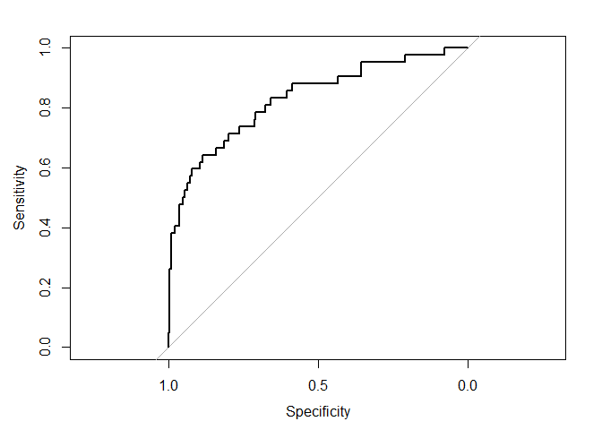

```r
plot(roc_obj_Step)
```

```r
#get the "best" "threshold"
coords(roc_obj_Step, "best", "threshold")
```

```
##   threshold specificity sensitivity
##   0.2255507   0.8858447   0.6428571
```

```r
# using best threshold to create the result
Results_Step <- ifelse(predict_employee_Step > 0.07,"Yes","No")
confusionMatrix(as.factor(Results_Step), employee.test$Attrition)
```

```
## Confusion Matrix and Statistics
##
##           Reference
## Prediction  No Yes
##        No  164  11
##        Yes  55  31
##
##                Accuracy : 0.7471
##                  95% CI : (0.6898, 0.7987)
##     No Information Rate : 0.8391
##     P-Value [Acc > NIR] : 0.9999
##
##                   Kappa : 0.3421
##
##  Mcnemar's Test P-Value : 1.204e-07
##
##             Sensitivity : 0.7489
##             Specificity : 0.7381
##          Pos Pred Value : 0.9371
##          Neg Pred Value : 0.3605
##              Prevalence : 0.8391
##          Detection Rate : 0.6284
##    Detection Prevalence : 0.6705
##       Balanced Accuracy : 0.7435
##
##        'Positive' Class : No
##
```

### Naïve Bayes Classifier

```r
# Naive Bayes Model
NB_Model <- naiveBayes(Attrition~., data=employee.train)
#Predict using the Logistic Regression Model

pred_NB <- predict(NB_Model,newdata = employee.test)
roc_obj_NB <- roc(employee.test$Attrition, as.numeric(pred_NB))
#review the roc object
roc_obj_NB
```

```
##
## Call:
## roc.default(response = employee.test$Attrition, predictor = as.numeric(pred_NB))
##
## Data: as.numeric(pred_NB) in 219 controls (employee.test$Attrition No) < 42 cases (employee.test$Attrition Yes).
## Area under the curve: 0.7259
```

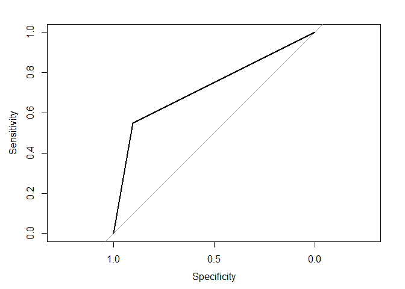

```r
plot(roc_obj_NB)
```

```r
#get the "best" "threshold"
coords(roc_obj_NB, "best", "threshold")
```

```
##   threshold specificity sensitivity
##   1.5000000   0.9041096   0.5476190
```

```r
#Evaluating the model
confusionMatrix(pred_NB, employee.test$Attrition)
```

```
## Confusion Matrix and Statistics
##
##           Reference
## Prediction  No Yes
##        No  198  19
##        Yes  21  23
##
##                Accuracy : 0.8467
##                  95% CI : (0.7972, 0.8882)
##     No Information Rate : 0.8391
##     P-Value [Acc > NIR] : 0.4072
##
##                   Kappa : 0.4432
##
##  Mcnemar's Test P-Value : 0.8744
##
##             Sensitivity : 0.9041
##             Specificity : 0.5476
##          Pos Pred Value : 0.9124
##          Neg Pred Value : 0.5227
##              Prevalence : 0.8391
##          Detection Rate : 0.7586
##    Detection Prevalence : 0.8314
##       Balanced Accuracy : 0.7259
##
##        'Positive' Class : No
##
```

```r
# predict Attrition for CaseStudy2Validation No Attrition dataset
NewPredict <- predict(StepModel,newdata = employee_Attrition_Test,type = 'response')
NewResults <- ifelse(NewPredict > 0.07,"Yes","No")
employee_Attrition_Test$Attrition <- NewResults
write.csv(employee_Attrition_Test,"Case2PredictionsAnsari Attrition.csv", quote = F)
```

## linear regression to predict Monthly Income

```r
# perform best subset selection
Linear_Model <- lm(MonthlyIncome ~ ., employee.train)
preds_Linear = predict(Linear_Model, newdata = employee.test)
RMSEfull <- RMSE(preds_Linear,employee.train$MonthlyIncome)
RMSEfull
```

```
## [1] 6329.81
```

```r
# selecting best model by comparing AIC in stepwise method
Linear_step_Model <- stepAIC(Linear_Model, direction="both", trace = F)
#final model
Linear_step_Model$anova
```

```
## Stepwise Model Path
## Analysis of Deviance Table
##
## Initial Model:
## MonthlyIncome ~ Age + Attrition + BusinessTravel + DailyRate +
##     Department + DistanceFromHome + Education + EducationField +
##     EnvironmentSatisfaction + Gender + HourlyRate + JobInvolvement +
##     JobLevel + JobRole + JobSatisfaction + MaritalStatus + MonthlyRate +
##     NumCompaniesWorked + OverTime + PercentSalaryHike + PerformanceRating +
##     RelationshipSatisfaction + StockOptionLevel + TotalWorkingYears +
##     TrainingTimesLastYear + WorkLifeBalance + YearsAtCompany +
##     YearsInCurrentRole + YearsSinceLastPromotion + YearsWithCurrManager +
##     Rand
##
## Final Model:
```

[output cut: 58 more lines]

```r
summary(Linear_step_Model)
```

```
##
## Call:
## lm(formula = MonthlyIncome ~ DailyRate + Gender + JobLevel +
##     JobRole + PerformanceRating + TotalWorkingYears, data = employee.train)
##
## Residuals:
##     Min      1Q  Median      3Q     Max
## -3080.1  -640.8   -41.7   599.2  4077.7
##
## Coefficients:
##                                 Estimate Std. Error t value Pr(>|t|)
## (Intercept)                    3539.6612   244.3818  14.484  < 2e-16 ***
## DailyRate                         0.2929     0.1045   2.802  0.00524 **
## GenderMale                      128.6783    85.7882   1.500  0.13416
## JobLevel2                      1449.8984   172.8087   8.390 3.57e-16 ***
## JobLevel3                      4571.4462   236.2772  19.348  < 2e-16 ***
## JobLevel4                      7912.7380   347.2957  22.784  < 2e-16 ***
## JobLevel5                     10645.8589   425.7179  25.007  < 2e-16 ***
## JobRoleHuman Resources        -1198.6665   309.6134  -3.871  0.00012 ***
## JobRoleLaboratory Technician  -1418.9025   214.6251  -6.611 8.53e-11 ***
## JobRoleManager                 3502.0857   288.4987  12.139  < 2e-16 ***
## JobRoleManufacturing Director   229.2799   192.6243   1.190  0.23441
## JobRoleResearch Director       3600.6546   273.1964  13.180  < 2e-16 ***
## JobRoleResearch Scientist     -1213.9789   216.2053  -5.615 3.03e-08 ***
## JobRoleSales Executive           78.9018   164.2032   0.481  0.63104
## JobRoleSales Representative   -1610.3224   265.3138  -6.070 2.29e-09 ***
## PerformanceRating4             -200.9424   117.9852  -1.703  0.08907 .
## TotalWorkingYears                45.9781     9.2905   4.949 9.74e-07 ***
## ---
## Signif. codes:  0 '***' 0.001 '**' 0.01 '*' 0.05 '.' 0.1 ' ' 1
##
## Residual standard error: 1023 on 592 degrees of freedom
## Multiple R-squared:   0.95,  Adjusted R-squared:  0.9486
## F-statistic: 702.5 on 16 and 592 DF,  p-value: < 2.2e-16
```

```r
# predictions of the model on test dataset

preds_Linear_step = predict(Linear_step_Model, newdata = employee.test)


# selecting best model by comparing AIC in forward method
forward_Model <- stepAIC(Linear_Model, direction="forward",trace = F)
#final model
forward_Model$anova
```

```
## Stepwise Model Path
## Analysis of Deviance Table
##
## Initial Model:
## MonthlyIncome ~ Age + Attrition + BusinessTravel + DailyRate +
##     Department + DistanceFromHome + Education + EducationField +
##     EnvironmentSatisfaction + Gender + HourlyRate + JobInvolvement +
##     JobLevel + JobRole + JobSatisfaction + MaritalStatus + MonthlyRate +
##     NumCompaniesWorked + OverTime + PercentSalaryHike + PerformanceRating +
##     RelationshipSatisfaction + StockOptionLevel + TotalWorkingYears +
##     TrainingTimesLastYear + WorkLifeBalance + YearsAtCompany +
##     YearsInCurrentRole + YearsSinceLastPromotion + YearsWithCurrManager +
##     Rand
##
## Final Model:
## MonthlyIncome ~ Age + Attrition + BusinessTravel + DailyRate +
##     Department + DistanceFromHome + Education + EducationField +
##     EnvironmentSatisfaction + Gender + HourlyRate + JobInvolvement +
##     JobLevel + JobRole + JobSatisfaction + MaritalStatus + MonthlyRate +
##     NumCompaniesWorked + OverTime + PercentSalaryHike + PerformanceRating +
##     RelationshipSatisfaction + StockOptionLevel + TotalWorkingYears +
##     TrainingTimesLastYear + WorkLifeBalance + YearsAtCompany +
##     YearsInCurrentRole + YearsSinceLastPromotion + YearsWithCurrManager +
##     Rand
##
##
##   Step Df Deviance Resid. Df Resid. Dev      AIC
## 1                        532  566642949 8523.744
```

```r
summary(forward_Model)
```

```
##
## Call:
## lm(formula = MonthlyIncome ~ Age + Attrition + BusinessTravel +
##     DailyRate + Department + DistanceFromHome + Education + EducationField +
##     EnvironmentSatisfaction + Gender + HourlyRate + JobInvolvement +
##     JobLevel + JobRole + JobSatisfaction + MaritalStatus + MonthlyRate +
##     NumCompaniesWorked + OverTime + PercentSalaryHike + PerformanceRating +
##     RelationshipSatisfaction + StockOptionLevel + TotalWorkingYears +
##     TrainingTimesLastYear + WorkLifeBalance + YearsAtCompany +
##     YearsInCurrentRole + YearsSinceLastPromotion + YearsWithCurrManager +
##     Rand, data = employee.train)
##
## Residuals:
##     Min      1Q  Median      3Q     Max
## -2592.5  -619.2   -31.8   591.7  3997.2
##
## Coefficients:
##                                    Estimate Std. Error t value Pr(>|t|)
## (Intercept)                       2.989e+03  8.843e+02   3.381 0.000777
## Age                              -5.245e+00  6.953e+00  -0.754 0.450962
## AttritionYes                      8.897e+01  1.462e+02   0.608 0.543125
## BusinessTravelTravel_Frequently   6.920e+01  1.656e+02   0.418 0.676187
## BusinessTravelTravel_Rarely       1.676e+02  1.382e+02   1.213 0.225716
## DailyRate                         2.999e-01  1.111e-01   2.699 0.007180
## DepartmentResearch & Development  2.677e+02  6.036e+02   0.443 0.657631
## DepartmentSales                  -3.659e+02  6.387e+02  -0.573 0.566946
## DistanceFromHome                 -3.595e+00  5.419e+00  -0.663 0.507338
## Education2                       -1.010e+02  1.655e+02  -0.610 0.542038
## Education3                       -1.682e+02  1.495e+02  -1.126 0.260837
## Education4                       -2.671e+01  1.632e+02  -0.164 0.870075
## Education5                       -6.255e+02  3.026e+02  -2.067 0.039195
## EducationFieldLife Sciences       8.572e+01  4.480e+02   0.191 0.848328
## EducationFieldMarketing           1.553e+02  4.797e+02   0.324 0.746311
## EducationFieldMedical             7.691e+01  4.513e+02   0.170 0.864759
## EducationFieldOther               3.540e+02  4.870e+02   0.727 0.467513
## EducationFieldTechnical Degree    4.386e+01  4.630e+02   0.095 0.924562
## EnvironmentSatisfaction2          2.530e+01  1.421e+02   0.178 0.858786
## EnvironmentSatisfaction3          4.544e+01  1.313e+02   0.346 0.729425
## EnvironmentSatisfaction4          2.201e+01  1.323e+02   0.166 0.867987
## GenderMale                        1.318e+02  8.906e+01   1.480 0.139449
```

[output cut: 124 more lines]

```
## TrainingTimesLastYear6
## WorkLifeBalance2
## WorkLifeBalance3
## WorkLifeBalance4
## YearsAtCompany
## YearsInCurrentRole
## YearsSinceLastPromotion
## YearsWithCurrManager
## Rand
## ---
## Signif. codes:  0 '***' 0.001 '**' 0.01 '*' 0.05 '.' 0.1 ' ' 1
##
## Residual standard error: 1032 on 532 degrees of freedom
## Multiple R-squared:  0.9542, Adjusted R-squared:  0.9477
## F-statistic: 145.9 on 76 and 532 DF,  p-value: < 2.2e-16
```

```r
# predictions of the model on test dataset

preds_Linear_forward = predict(forward_Model, newdata = employee.test)

# Evaluating both model
# Calculation of the ASE for the training set
ASEholderStep = sum((preds_Linear_step - employee.test$MonthlyIncome)^2)/(length(employee.test$MonthlyIncome))
# Calculation of the ASE for the Test set
ASEholderForward = sum((preds_Linear_forward- employee.test$MonthlyIncome)^2)/(length(employee.test$MonthlyIncome))
# comparing ASEs
ASEholderStep
```

```
## [1] 964200
```

```r
ASEholderForward
```

```
## [1] 1069534
```

```r
# comparing RSME
RMSEstep <- RMSE(preds_Linear_step,employee.test$MonthlyIncome)
RMSEstep
```

```
## [1] 981.9369
```

```r
RMSEforward <- RMSE(preds_Linear_forward,employee.test$MonthlyIncome)
RMSEforward
```

```
## [1] 1034.183
```

```r
# predicting Monthly Income for CaseStudy2Validation No Salary data
preds_Linear_final = predict(Linear_step_Model, newdata = employee_Salary_Test)
employee_Salary_Test$MonthlyRate <- preds_Linear_final
```

Stepwise model gives us lower ASE and RMSE which used as final model to predict monthly income for CaseStudy2Validation NO Salary.csv dataset.

```r
# predict MOnthlyIncom for CaseStudy2Validation No Salary
NewPredictSalary <- predict(Linear_step_Model,newdata = employee_Salary_Test)
employee_Salary_Test$MonthlyIncome <- NewPredictSalary
write.csv(employee_Salary_Test,"CaseStudy2ValidationAnsari Salary.csv")
```

## Conclusion

Project requirement is to find model to predict attrition with more than 60% sensitivity and specificity. Two machine learning methods are used, and logistic regression stepwise model gives us 75% accuracy, 75% sensitivity and 74% specificity with classifier threshold qual to 0.07. To predict monthly income linear regression method has been used and setpwise model gave us lower ASE and RMSE. Adjusted R-Square for this model is 94% and p-value is less than 0.0001 which means at least one variable explains monthly salary. There is obviously room for further analysis and improvement and tuning of the models. In addition, more classifiers and different architectures can be tested in future attempts.